# Step 1.a -- Student A

```python
# Get optimum parameter values
# lamb, mu, delta
student_C_jump_params = N_B96_calibration_short()

print("Optimum parameters =", student_C_jump_params)
```

```
   0 | [ 0.  -0.5  0. ] |   1.264 |   1.264
  25 | [ 0.2  -0.5   0.25] |   3.968 |   1.264
  50 | [ 0.4 -0.5  0.5] |  15.068 |   1.264
  75 | [ 0.0e+00 -5.0e-01  2.5e-04] |   1.264 |   1.264
 100 | [ 7.45058060e-12 -5.08333333e-01  8.33333308e-05] |   1.264 |   1.264
 125 | [ 1.58798212e-14 -4.97457097e-01  1.63866027e-04] |   1.264 |   1.264
 150 | [ 1.12805433e-14 -5.01532281e-01  1.63583819e-04] |   1.264 |   1.264
 175 | [ 1.13496132e-14 -5.01879240e-01  1.63580359e-04] |   1.264 |   1.264
 200 | [ 1.13517717e-14 -5.01890082e-01  1.63580250e-04] |   1.264 |   1.264
Optimization terminated successfully.
         Current function value: 1.264124
         Iterations: 63
         Function evaluations: 175
Optimum parameters = [ 1.13518413e-14 -5.01890432e-01  1.63580247e-04]
```

```python
n_p0 = [student_C_heston_params[0], student_C_heston_params[1], student_C_heston_params[2], student_C_heston_params[3], student_C_heston_params[4],
        student_C_jump_params[0], student_C_jump_params[1], student_C_jump_params[2]]
```

```python
i = 0
min_MSE = 5000.0


def N_B96_full_error_function(n_p0):
    global i, min_MSE
    kappa_v, theta_v, sigma_v, rho, v0 = student_C_heston_params
    lamb, mu, delta = student_C_jump_params
    # = p0

    if (
        kappa_v < 0.0
        or theta_v < 0.005
        or sigma_v < 0.0
        or rho < -1.0
        or rho > 1.0
        or v0 < 0.0
        or lamb < 0.0
        or mu < -0.6
        or mu > 0.0
        or delta < 0.0
    ):
        return 5000.0

    if 2 * kappa_v * theta_v < sigma_v**2:
        return 5000.0

    se = []
    for row, option in options_60_DTM.iterrows():
        model_value = N_B96_call_value(
            S0,
            option["Strike"],
            option["T"],
            option["r"],
            kappa_v,
            theta_v,
            sigma_v,
            rho,
            v0,
            lamb,
            mu,
            delta,
        )
        se.append((model_value - option["Price"]) ** 2)

    MSE = sum(se) / len(se)
    min_MSE = min(min_MSE, MSE)
    if i % 25 == 0:
        print("%4d |" % i, np.array(n_p0), "| %7.3f | %7.3f" % (MSE, min_MSE))
    i += 1
    return MSE

def N_B96_calibration_full():
    opt = fmin(
        N_B96_full_error_function, n_p0, xtol=0.001, ftol=0.001, maxiter=1250, maxfun=650
    )
    return opt
```

```python
# Get optimum parameter values
# kappa_v, theta_v, sigma_v, rho, v0, lamb, mu, delta
student_C_full_bates_params = N_B96_calibration_full()

print("Optimum parameters =", student_C_full_bates_params)
```

```
   0 | [ 1.49302355e+01  1.49010912e-01  1.01234332e-03 -7.09440841e-03
  4.80245567e-02  1.13518413e-14 -5.01890432e-01  1.63580247e-04] |   1.264 |   1.264
  25 | [ 1.49302355e+01  1.49010912e-01  1.01234332e-03 -7.09440841e-03
  4.86248637e-02  1.13518413e-14 -5.01890432e-01  1.63580247e-04] |   1.264 |   1.264
  50 | [ 1.49331515e+01  1.49040016e-01  1.01254104e-03 -7.09579404e-03
  4.80339365e-02  1.13540584e-14 -5.01988458e-01  1.63835841e-04] |   1.264 |   1.264
  75 | [ 1.49302355e+01  1.49010912e-01  1.01234332e-03 -7.09440841e-03
  4.80433163e-02  1.13518413e-14 -5.01890432e-01  1.63580247e-04] |   1.264 |   1.264
 100 | [ 1.49303266e+01  1.49011822e-01  1.01234950e-03 -7.09445171e-03
  4.80248498e-02  1.13519106e-14 -5.01893495e-01  1.63588234e-04] |   1.264 |   1.264
Optimization terminated successfully.
         Current function value: 1.264124
         Iterations: 11
         Function evaluations: 109
Optimum parameters = [ 1.49302355e+01  1.49010912e-01  1.01234332e-03 -7.09440841e-03
  4.80245567e-02  1.13518413e-14 -5.01890432e-01  1.63580247e-04]
```

```python
def N_B96_calculate_model_values(p0):
    kappa_v, theta_v, sigma_v, rho, v0, lamb, mu, delta = p0
    values = []
    for row, option in options_60_DTM.iterrows():
        model_value = N_B96_call_value(
            S0,
            option["Strike"],
            option["T"],
            option["r"],
            kappa_v,
            theta_v,
            sigma_v,
            rho,
            v0,
            lamb,
            mu,
            delta,
        )

        values.append(model_value)

    return np.array(values)
```

```python
def N_B96_plot_full_calibration_results(p0):
    options_60_DTM["Model"] = N_B96_calculate_model_values(p0)
    plt.figure(figsize=(8, 6))
    plt.subplot(211)
    plt.grid()
    #plt.title("Maturity %s" % str(options_60_DTM["Maturity"].iloc[0])[:10])
    plt.ylabel("option values")
    plt.plot(options_60_DTM.Strike, options_60_DTM.Price, "b", label="market")
    plt.plot(options_60_DTM.Strike, options_60_DTM.Model, "ro", label="model")
    plt.legend(loc=0)
    plt.axis(
        [
            min(options_60_DTM.Strike) - 10,
            max(options_60_DTM.Strike) + 10,
            min(options_60_DTM.Price) - 10,
            max(options_60_DTM.Price) + 10,
        ]
    )
    plt.subplot(212)
    plt.grid()
    wi = 5.0
    diffs = options_60_DTM.Model.values - options_60_DTM.Price.values
    plt.bar(options_60_DTM.Strike.values - wi / 2, diffs, width=wi)
    plt.ylabel("difference")
    plt.axis(
        [
            min(options_60_DTM.Strike) - 10,
            max(options_60_DTM.Strike) + 10,
            min(diffs) * 1.1,
            max(diffs) * 1.1,
        ]
    )
    plt.tight_layout()
```

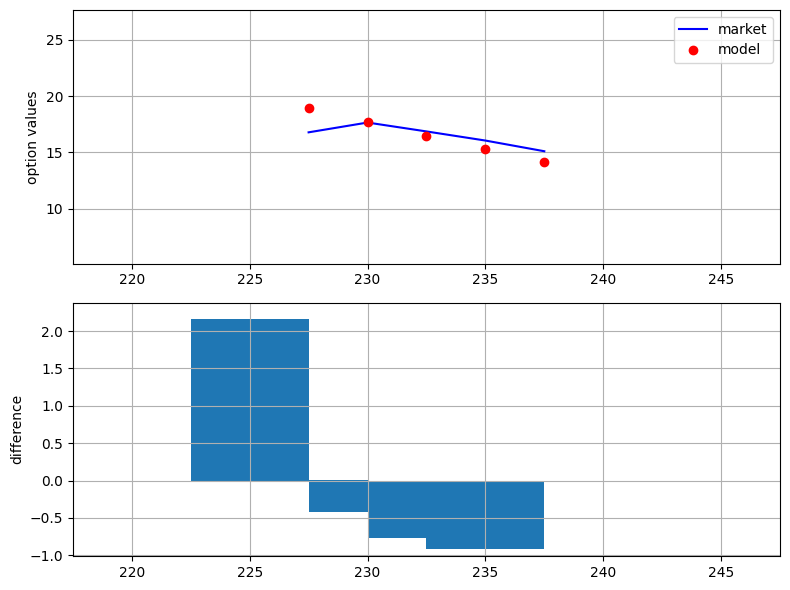

```python
N_B96_plot_full_calibration_results(n_p0)
```

# Step 2.b -- Student A

```python
# Given parameters
r = 1.50 / 100
trading_days = 250
S0 = 232.90

# Load data
options = df
options["T"] = options["Days_to_Maturity"] / trading_days
options["r"] = r


# Filter 15 days maturity calls
options = options[(options['Days_to_Maturity'] == 60) & (options['Type'] == 'C')]
options
```

|  | Days_to_Maturity | Strike | Price | Type | T | r |
| --- | --- | --- | --- | --- | --- | --- |
| 5 | 60 | 227.5 | 16.78 | C | 0.24 | 0.015 |
| 6 | 60 | 230.0 | 17.65 | C | 0.24 | 0.015 |
| 7 | 60 | 232.5 | 16.86 | C | 0.24 | 0.015 |
| 8 | 60 | 235.0 | 16.05 | C | 0.24 | 0.015 |
| 9 | 60 | 237.5 | 15.10 | C | 0.24 | 0.015 |

```python
def M76J_char_func(u, T, lamb, mu, delta):
    """
    Adjusted Characteristic function for Merton '76 model: Only jump component
    """

    omega = -lamb * (np.exp(mu + 0.5 * delta**2) - 1)
    char_func_value = np.exp(
        (1j * u * omega + lamb * (np.exp(1j * u * mu - u**2 * delta**2 * 0.5) - 1))
        * T
    )
    return char_func_value

def B96_char_func(u, T, r, kappa_v, theta_v, sigma_v, rho, v0, lamb, mu, delta):
    """
    Bates (1996) characteristic function
    """
    H93 = H93_char_func(u, T, r, kappa_v, theta_v, sigma_v, rho, v0)
    M76J = M76J_char_func(u, T, lamb, mu, delta)
    return H93 * M76J


def B96_call_FFT(S0, K, T, r, kappa_v, theta_v, sigma_v, rho, v0, lamb, mu, delta):
    """
    Call option price in Bates (1996) under FFT
    """

    k = np.log(K / S0)
    g = 1  # Factor to increase accuracy
    N = g * 4096
    eps = (g * 150) ** -1
    eta = 2 * np.pi / (N * eps)
    b = 0.5 * N * eps - k
    u = np.arange(1, N + 1, 1)
    vo = eta * (u - 1)

    # Modifications to ensure integrability
    if S0 >= 0.95 * K:  # ITM Case
        alpha = 1.5
        v = vo - (alpha + 1) * 1j
        modcharFunc = np.exp(-r * T) * (
            B96_char_func(v, T, r, kappa_v, theta_v, sigma_v, rho, v0, lamb, mu, delta)
            / (alpha**2 + alpha - vo**2 + 1j * (2 * alpha + 1) * vo)
        )

    else:
        alpha = 1.1
        v = (vo - 1j * alpha) - 1j
        modcharFunc1 = np.exp(-r * T) * (
            1 / (1 + 1j * (vo - 1j * alpha))
            - np.exp(r * T) / (1j * (vo - 1j * alpha))
            - B96_char_func(
                v, T, r, kappa_v, theta_v, sigma_v, rho, v0, lamb, mu, delta
            )
            / ((vo - 1j * alpha) ** 2 - 1j * (vo - 1j * alpha))
        )

        v = (vo + 1j * alpha) - 1j

        modcharFunc2 = np.exp(-r * T) * (
            1 / (1 + 1j * (vo + 1j * alpha))
            - np.exp(r * T) / (1j * (vo + 1j * alpha))
            - B96_char_func(
                v, T, r, kappa_v, theta_v, sigma_v, rho, v0, lamb, mu, delta
            )
            / ((vo + 1j * alpha) ** 2 - 1j * (vo + 1j * alpha))
        )

    # Numerical FFT Routine
    delt = np.zeros(N)
    delt[0] = 1
    j = np.arange(1, N + 1, 1)
    SimpsonW = (3 + (-1) ** j - delt) / 3
    if S0 >= 0.95 * K:
        FFTFunc = np.exp(1j * b * vo) * modcharFunc * eta * SimpsonW
        payoff = (np.fft.fft(FFTFunc)).real
        CallValueM = np.exp(-alpha * k) / np.pi * payoff
    else:
        FFTFunc = (
            np.exp(1j * b * vo) * (modcharFunc1 - modcharFunc2) * 0.5 * eta * SimpsonW
        )
        payoff = (np.fft.fft(FFTFunc)).real
        CallValueM = payoff / (np.sinh(alpha * k) * np.pi)

    pos = int((k + b) / eps)
    CallValue = CallValueM[pos] * S0

    return CallValue

def put_price_from_call(call_price, S0, K, T, r):
    """
    Calculates the European put option price using Put-Call parity.

    Parameters:
    ===========
    call_price : float
        Price of the European call option.
    S0 : float
        Current stock/index level.
    K : float
        Strike price.
    T : float
        Time to maturity (in years).
    r : float
        Constant risk-free short rate.

    Returns:
    ========
    put_price : float
        Price of the European put option.
    """
    put_price = call_price + K * np.exp(-r * T) - S0
    return put_price
```

```python
# H93 Calibration

i = 0
min_MSE = 500

def H93_error_function(p0):
    """Error function for parameter calibration via
    Lewis (2001) Fourier approach for Heston (1993).
    Parameters
    ==========
    kappa_v: float
        mean-reversion factor
    theta_v: float
        long-run mean of variance
    sigma_v: float
        volatility of variance
    rho: float
        correlation between variance and stock/index level
    v0: float
        initial, instantaneous variance
    Returns
    =======
    MSE: float
        mean squared error
    """
    global i, min_MSE
    kappa_v, theta_v, sigma_v, rho, v0 = p0
    if kappa_v < 0.0 or theta_v < 0.005 or sigma_v < 0.0 or rho < -1.0 or rho > 1.0:
        return 500.0
    if 2 * kappa_v * theta_v < sigma_v**2:
        return 500.0
    se = []
    for row, option in options.iterrows():
        model_value = H93_call_FFT(
            S0,
            option["Strike"],
            option["T"],
            option["r"],
            kappa_v,
            theta_v,
            sigma_v,
            rho,
            v0,
        )
        se.append((model_value - option["Price"]) ** 2)
    MSE = sum(se) / len(se)
    min_MSE = min(min_MSE, MSE)
    if i % 25 == 0:
        print("%4d |" % i, np.array(p0), "| %7.3f | %7.3f" % (MSE, min_MSE))
    i += 1
    return MSE

def H93_calibration_full():
    """Calibrates Heston (1993) stochastic volatility model to market quotes."""
    # First run with brute force
    # (scan sensible regions, for faster convergence)
    p0 = brute(
        H93_error_function,
        (
            (2.5, 10.6, 1.0),  # kappa_v
            (0.01, 0.041, 0.01),  # theta_v
            (0.05, 0.251, 0.01),  # sigma_v
            (-0.75, 0.01, 0.1),  # rho
            (0.01, 0.031, 0.01),  # v0
        ),
        finish=None,
    )

    # Second run with local, convex minimization
    # (we dig deeper where promising results)
    opt = fmin(
        H93_error_function, p0, xtol=0.000001, ftol=0.000001, maxiter=1500, maxfun=900
    )
    return opt

def H93_calculate_model_values(p0):
    kappa_v, theta_v, sigma_v, rho, v0 = p0
    values = []
    for row, option in options.iterrows():
        model_value = H93_call_FFT(
            S0,
            option["Strike"],
            option["T"],
            option["r"],
            kappa_v,
            theta_v,
            sigma_v,
            rho,
            v0
        )

        values.append(model_value)

    return np.array(values)
```

```python
# Get optimum parameter values
kappa_v, theta_v, sigma_v, rho, v0 = H93_calibration_full()
student_A_full_params = kappa_v, theta_v, sigma_v, rho, v0

print("Optimum parameters =", student_A_full_params)
```

```
   0 | [ 2.5   0.01  0.05 -0.75  0.01] | 124.804 | 124.804
  25 | [ 2.5   0.01  0.06 -0.75  0.02] |  95.423 |  74.487
  50 | [ 2.5   0.01  0.07 -0.75  0.03] |  74.562 |  74.487
  75 | [ 2.5   0.01  0.08 -0.65  0.01] | 124.980 |  74.487
 100 | [ 2.5   0.01  0.09 -0.65  0.02] |  95.594 |  74.487
 125 | [ 2.5   0.01  0.1  -0.65  0.03] |  74.726 |  74.487
 150 | [ 2.5   0.01  0.11 -0.55  0.01] | 125.279 |  74.487
 175 | [ 2.5   0.01  0.12 -0.55  0.02] |  95.850 |  74.487
 200 | [ 2.5   0.01  0.13 -0.55  0.03] |  74.951 |  74.487
 225 | [ 2.5   0.01  0.14 -0.45  0.01] | 125.695 |  74.487
 250 | [ 2.5   0.01  0.15 -0.45  0.02] |  96.190 |  74.487
 275 | [ 2.5   0.01  0.16 -0.45  0.03] |  75.236 |  74.487
 300 | [ 2.5   0.01  0.17 -0.35  0.01] | 126.218 |  74.487
 325 | [ 2.5   0.01  0.18 -0.35  0.02] |  96.611 |  74.487
 350 | [ 2.5   0.01  0.19 -0.35  0.03] |  75.579 |  74.487
```

[output cut: 769 more lines]

```python
i = 0
miMSE = 5000.0
local_opt = False

def B96_error_function(p0):
    """
    Error function for Bates (1996) model

    Parameters:
    -------------
    lamb: float
        jump intensity
    mu: float
        expected jump size
    delta: float
        standard deviation of jump
    Returns
    -------------
    MSE: float
        mean squared error
    """

    global i, miMSE, local_opt, opt1
    lamb, mu, delta = p0
    if lamb < 0.0 or mu < -0.6 or mu > 0.0 or delta < 0.0:
        return 5000.0
    se = []
    for row, option in options_60_DTM.iterrows():
        model_value = B96_call_value(
            S0,
            option["Strike"],
            option["T"],
            option["r"],
            student_A_full_params[0],#kappa_v,
            student_A_full_params[1],#theta_v,
            student_A_full_params[2],#sigma_v,
            student_A_full_params[3],#rho,
            student_A_full_params[4],#v0,
            lamb,
            mu,
            delta,
        )
        se.append((model_value - option["Price"]) ** 2)
    MSE = sum(se) / len(se)
    miMSE = min(miMSE, MSE)
    if i % 25 == 0:
        print("%4d |" % i, np.array(p0), "| %7.3f | %7.3f" % (MSE, miMSE))
    i += 1
    if local_opt:
        penalty = np.sqrt(np.sum((p0 - opt1) ** 2)) * 1
        return MSE + penalty
    return MSE

def B96_call_value(S0, K, T, r, kappa_v, theta_v, sigma_v, rho, v0, lamb, mu, delta):
    """
    Valuation of European call option in B96 Model via Lewis (2001)
    Parameters:
    ==========
    S0: float
        initial stock/index level
    K: float
        strike price
    T: float
        time-to-maturity (for t=0)
    r: float
        constant risk-free short rate
    kappa_v: float
        mean-reversion factor
    theta_v: float
        long-run mean of variance
    sigma_v: float
        volatility of variance
    rho: float
        correlation between variance and stock/index level
    v0: float
        initial level of variance
    lamb: float
        jump intensity
    mu: float
        expected jump size
    delta: float
        standard deviation of jump
    ==========
    """
    int_value = quad(
        lambda u: B96_int_func(
            u, S0, K, T, r, kappa_v, theta_v, sigma_v, rho, v0, lamb, mu, delta
        ),
        0,
        np.inf,
        limit=250,
    )[0]
    call_value = max(0, S0 - np.exp(-r * T) * np.sqrt(S0 * K) / np.pi * int_value)
    return call_value

def M76J_char_func(u, T, lamb, mu, delta):
    """
    Adjusted Characteristic function for Merton '76 model: Only jump component
    """

    omega = -lamb * (np.exp(mu + 0.5 * delta**2) - 1)
    char_func_value = np.exp(
        (1j * u * omega + lamb * (np.exp(1j * u * mu - u**2 * delta**2 * 0.5) - 1))
        * T
    )
    return char_func_value

def B96_char_func(u, T, r, kappa_v, theta_v, sigma_v, rho, v0, lamb, mu, delta):
    """
    Bates (1996) characteristic function
    """
    H93 = H93_char_func(u, T, r, kappa_v, theta_v, sigma_v, rho, v0)
    M76J = M76J_char_func(u, T, lamb, mu, delta)
    return H93 * M76J

def B96_int_func(u, S0, K, T, r, kappa_v, theta_v, sigma_v, rho, v0, lamb, mu, delta):
    """
    Lewis (2001) integral value for Bates (1996) characteristic function
    """
    char_func_value = B96_char_func(
        u - 1j * 0.5, T, r, kappa_v, theta_v, sigma_v, rho, v0, lamb, mu, delta
    )
    int_func_value = (
        1 / (u**2 + 0.25) * (np.exp(1j * u * np.log(S0 / K)) * char_func_value).real
    )
    return int_func_value

def B96_calibratioshort():
    """
    Calibrates jump component of Bates (1996) model to market prices
    """
    # First, we run with brute force
    # (scan sensible regions)
    opt1 = 0.0
    opt1 = brute(
        B96_error_function,
        (
            (0.0, 0.51, 0.1),  # lambda
            (-0.5, -0.11, 0.1),  # mu
            (0.0, 0.51, 0.25),
        ),  # delta
        finish=None,
    )

    # Second, we run with local, convex minimization
    # (dig deeper where promising)
    opt2 = fmin(
        B96_error_function,
        opt1,
        xtol=0.0000001,
        ftol=0.0000001,
        maxiter=550,
        maxfun=750,
    )
    return opt2
```

```python
# Get optimum parameter values
# lamb, mu, delta
student_A_jump_params = B96_calibratioshort()

print("Optimum parameters =", student_A_jump_params)
```

```
   0 | [ 0.  -0.5  0. ] |   1.264 |   1.264
  25 | [ 0.2  -0.5   0.25] |   3.967 |   1.264
  50 | [ 0.4 -0.5  0.5] |  15.067 |   1.264
  75 | [ 0.0e+00 -5.0e-01  2.5e-04] |   1.264 |   1.264
 100 | [ 7.45058060e-12 -5.08333333e-01  8.33333308e-05] |   1.264 |   1.264
 125 | [ 2.21310377e-14 -5.06944444e-01  7.98611111e-05] |   1.264 |   1.264
 150 | [ 2.36279144e-14 -5.07183160e-01  7.34592014e-05] |   1.264 |   1.264
 175 | [ 2.36462701e-14 -5.07288276e-01  7.29336209e-05] |   1.264 |   1.264
 200 | [ 2.36468437e-14 -5.07291561e-01  7.29171965e-05] |   1.264 |   1.264
Optimization terminated successfully.
         Current function value: 1.264122
         Iterations: 57
         Function evaluations: 171
Optimum parameters = [ 2.36468622e-14 -5.07291667e-01  7.29166667e-05]
```

```python
p0 = [student_A_full_params[0], student_A_full_params[1], student_A_full_params[2], student_A_full_params[3], student_A_full_params[4],
        student_A_jump_params[0], student_A_jump_params[1], student_A_jump_params[2]]
```

```python
i = 0
miMSE = 5000.0


def B96_full_error_function(p0):
    global i, miMSE
    kappa_v, theta_v, sigma_v, rho, v0 = student_A_full_params
    lamb, mu, delta = student_A_jump_params
    # = p0

    if (
        kappa_v < 0.0
        or theta_v < 0.005
        or sigma_v < 0.0
        or rho < -1.0
        or rho > 1.0
        or v0 < 0.0
        or lamb < 0.0
        or mu < -0.6
        or mu > 0.0
        or delta < 0.0
    ):
        return 5000.0

    if 2 * kappa_v * theta_v < sigma_v**2:
        return 5000.0

    se = []
    for row, option in options_60_DTM.iterrows():
        model_value = B96_call_value(
            S0,
            option["Strike"],
            option["T"],
            option["r"],
            kappa_v,
            theta_v,
            sigma_v,
            rho,
            v0,
            lamb,
            mu,
            delta,
        )
        se.append((model_value - option["Price"]) ** 2)

    MSE = sum(se) / len(se)
    miMSE = min(miMSE, MSE)
    if i % 25 == 0:
        print("%4d |" % i, np.array(p0), "| %7.3f | %7.3f" % (MSE, miMSE))
    i += 1
    return MSE

def B96_calibrationfull():
    opt = fmin(
        B96_full_error_function, p0, xtol=0.001, ftol=0.001, maxiter=1250, maxfun=650
    )
    return opt
```

```python
# Get optimum parameter values
# kappa_v, theta_v, sigma_v, rho, v0, lamb, mu, delta
student_A_full_bates_params = B96_calibrationfull()

print("Optimum parameters =", student_A_full_bates_params)
```

```
   0 | [ 2.03728542e+01  1.45031342e-01  1.65000651e-05 -3.45305193e-02
  2.96414376e-02  2.36468622e-14 -5.07291667e-01  7.29166667e-05] |   1.264 |   1.264
  25 | [ 2.03728542e+01  1.45031342e-01  1.65000651e-05 -3.45305193e-02
  3.00119556e-02  2.36468622e-14 -5.07291667e-01  7.29166667e-05] |   1.264 |   1.264
  50 | [ 2.03768332e+01  1.45059668e-01  1.65032877e-05 -3.45372636e-02
  2.96472270e-02  2.36514808e-14 -5.07390747e-01  7.30305990e-05] |   1.264 |   1.264
  75 | [ 2.03728542e+01  1.45031342e-01  1.65000651e-05 -3.45305193e-02
  2.96530163e-02  2.36468622e-14 -5.07291667e-01  7.29166667e-05] |   1.264 |   1.264
 100 | [ 2.03729785e+01  1.45032227e-01  1.65001658e-05 -3.45307301e-02
  2.96416186e-02  2.36470066e-14 -5.07294763e-01  7.29202270e-05] |   1.264 |   1.264
Optimization terminated successfully.
         Current function value: 1.264122
         Iterations: 11
         Function evaluations: 109
Optimum parameters = [ 2.03728542e+01  1.45031342e-01  1.65000651e-05 -3.45305193e-02
  2.96414376e-02  2.36468622e-14 -5.07291667e-01  7.29166667e-05]
```

```python
def B96_calculate_model_values(p0):
    kappa_v, theta_v, sigma_v, rho, v0, lamb, mu, delta = p0
    values = []
    for row, option in options.iterrows():
        model_value = B96_call_value(
            S0,
            option["Strike"],
            option["T"],
            option["r"],
            kappa_v,
            theta_v,
            sigma_v,
            rho,
            v0,
            lamb,
            mu,
            delta,
        )

        values.append(model_value)

    return np.array(values)
```

```python
def B96_plot_full_calibratioresults(p0):
    options["Model"] = B96_calculate_model_values(p0)
    plt.figure(figsize=(8, 6))
    plt.subplot(211)
    plt.grid()
    #plt.title("Maturity %s" % str(options["Maturity"].iloc[0])[:10])
    plt.ylabel("option values")
    plt.plot(options.Strike, options.Price, "b", label="market")
    plt.plot(options.Strike, options.Model, "ro", label="model")
    plt.legend(loc=0)
    plt.axis(
        [
            min(options.Strike) - 10,
            max(options.Strike) + 10,
            min(options.Price) - 10,
            max(options.Price) + 10,
        ]
    )
    plt.subplot(212)
    plt.grid()
    wi = 5.0
    diffs = options.Model.values - options.Price.values
    plt.bar(options.Strike.values - wi / 2, diffs, width=wi)
    plt.ylabel("difference")
    plt.axis(
        [
            min(options.Strike) - 10,
            max(options.Strike) + 10,
            min(diffs) * 1.1,
            max(diffs) * 1.1,
        ]
    )
    plt.tight_layout()
```

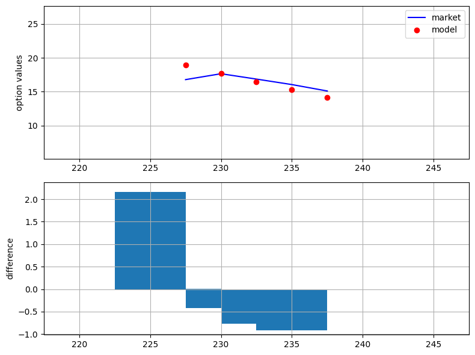

```python
B96_plot_full_calibratioresults(p0)
```

We used the Days to Maturity value of 60 days and the MSE as the error function of the model. As observed in the graphs, the modeled points for the calibration results follow a trend that is similar to the market option values reported, which suggests that the fit of the calibration is reasonably accurate enough to model option prices for a short time period.

# Step 2.c -- Student B

```
Simulating Heston Model Paths...
Simulation completed.

Pricing Asian Put Option...
Asian Put Option Price: $ 4.6964
95% Confidence Interval: [4.6398, 4.7530]
```

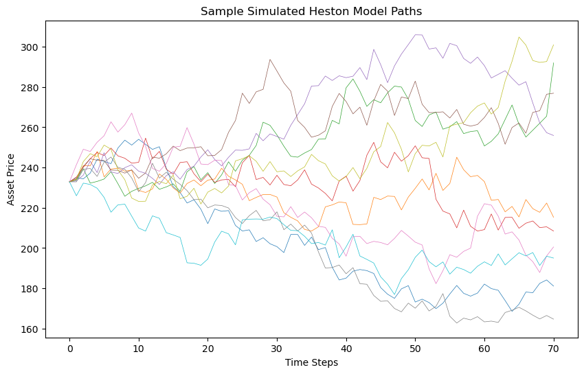

```python
# Given parameters
r = 1.50 / 100
trading_days = 250
S0 = 232.90
T = 70 / trading_days  # 70 days to maturity
K = 0.95 * S0  # 0.95 moneyness

def simulate_heston_paths(S0, T, r, kappa_v, theta_v, sigma_v, rho, v0,
                         num_simulations=100000, num_steps=70):
    """
    Simulate asset price paths under the Heston model using the Euler-Maruyama method
    with Full Truncation to ensure non-negative variance.

    Parameters:
    ===========
    S0 : float
        Initial asset price.
    T : float
        Time to maturity (in years).
    r : float
        Risk-free interest rate.
    kappa_v : float
        Mean-reversion rate of variance.
    theta_v : float
        Long-term mean of variance.
    sigma_v : float
        Volatility of variance.
    rho : float
        Correlation between the two Brownian motions.
    v0 : float
        Initial variance.
    num_simulations : int
        Number of Monte Carlo simulations.
    num_steps : int
        Number of time steps.

    Returns:
    ========
    S_paths : ndarray
        Simulated asset price paths of shape (num_simulations, num_steps + 1).
    """
    dt = T / num_steps
    # Initialize arrays
    S_paths = np.zeros((num_simulations, num_steps + 1))
    v_paths = np.zeros((num_simulations, num_steps + 1))
    S_paths[:, 0] = S0
    v_paths[:, 0] = v0

    # Precompute constants
    sqrt_dt = np.sqrt(dt)
    # Correlated random variables
    np.random.seed(42)  # For reproducibility
    Z1 = np.random.standard_normal((num_simulations, num_steps))
    Z2 = np.random.standard_normal((num_simulations, num_steps))
    W1 = Z1
    W2 = rho * Z1 + np.sqrt(1 - rho**2) * Z2

    for t in range(1, num_steps + 1):
        v_prev = v_paths[:, t - 1]
        # Ensure variance is non-negative (Full Truncation Euler)
        v_prev_clipped = np.maximum(v_prev, 0)
        # Update variance
        dv = kappa_v * (theta_v - v_prev_clipped) * dt + sigma_v * np.sqrt(v_prev_clipped) * sqrt_dt * W2[:, t - 1]
        v_new = v_prev + dv
        v_new = np.maximum(v_new, 0)  # Full Truncation
        v_paths[:, t] = v_new

        # Update asset price
        dS = r * S_paths[:, t - 1] * dt + np.sqrt(v_prev_clipped) * S_paths[:, t - 1] * sqrt_dt * W1[:, t - 1]
        S_new = S_paths[:, t - 1] + dS
        S_paths[:, t] = S_new

    return S_paths

def price_asian_put_mc(S_paths, K, r, T):
    """
    Price an Asian Put option using Monte Carlo simulation.

    Parameters:
    ===========
    S_paths : ndarray
        Simulated asset price paths of shape (num_simulations, num_steps + 1).
    K : float
        Strike price.
    r : float
        Risk-free interest rate.
    T : float
        Time to maturity (in years).

    Returns:
    ========
    put_price : float
        Estimated price of the Asian Put option.
    """
    # Include S0 in the average
    average_S = np.mean(S_paths, axis=1)
    # Calculate payoffs
    payoffs = np.maximum(K - average_S, 0)
    # Discount payoffs
    discounted_payoffs = np.exp(-r * T) * payoffs
    # Estimate option price
    put_price = np.mean(discounted_payoffs)
    # Calculate 95% confidence interval
    std_error = np.std(discounted_payoffs) / np.sqrt(len(discounted_payoffs))
    confidence_interval = (put_price - 1.96 * std_error, put_price + 1.96 * std_error)

    return put_price, confidence_interval

def calc_asian_put():
    # Given parameters
    r = 1.50 / 100  # Risk-free rate
    trading_days = 250
    S0 = 232.90  # Initial asset price
    T_days = 70  # Days to maturity
    T = T_days / trading_days  # Time to maturity in years
    K = 0.95 * S0  # Strike price (0.95 moneyness)

    # Calibrated Heston parameters (from calibration step)
    kappa_v, theta_v, sigma_v, rho, v0 = student_B_full_params

    # Monte Carlo parameters
    num_simulations = 100000  # Number of Monte Carlo simulations
    num_steps = T_days  # Daily steps

    print("\nSimulating Heston Model Paths...")
    S_paths = simulate_heston_paths(
        S0=S0,
        T=T,
        r=r,
        kappa_v=kappa_v,
        theta_v=theta_v,
        sigma_v=sigma_v,
        rho=rho,
        v0=v0,
        num_simulations=num_simulations,
        num_steps=num_steps
    )
    print("Simulation completed.")

    print("\nPricing Asian Put Option...")
    put_price, confidence_interval = price_asian_put_mc(S_paths, K, r, T)
    print(f"Asian Put Option Price: $ {put_price:.4f}")
    print(f"95% Confidence Interval: [{confidence_interval[0]:.4f}, {confidence_interval[1]:.4f}]")

    # Optional: Plot a few simulated paths
    plt.figure(figsize=(10,6))
    for i in range(10):
        plt.plot(S_paths[i, :], lw=0.5)
    plt.title('Sample Simulated Heston Model Paths')
    plt.xlabel('Time Steps')
    plt.ylabel('Asset Price')
    plt.show()

    return put_price

put_price = calc_asian_put()
```

```python
price_with_fee = put_price * 1.04
print("Asian Put Price with 4% fee: $", np.round(price_with_fee, 4))
```

```
Asian Put Price with 4% fee: $ 4.8842
```

### Brief description about the process to the client

To price the Asian Put option accurately, we employed the **Heston (1993)** Stochastic Volatility Model. The Heston model recognizes that volatility—a measure of an asset's price fluctuations—can vary over time, capturing more realistic market behaviors.

We began by sourcing real market data, specifically focusing on European call options with a 15-day maturity. This data includes various strike prices and corresponding option prices, which serve as benchmarks for **calibration**.

Using a **brute-force** approach, we scanned a range of plausible values for each parameter to identify regions where the model's outputs closely match market prices. Leveraging advanced optimization techniques, we fine-tuned these parameters to minimize discrepancies between the model's predictions and actual market data, ensuring the highest possible accuracy.

With calibrated parameters in hand, we proceeded to simulate the future behavior of the underlying asset's price. Once the asset price paths were simulated, we proceeded to determine the option's fair price based on these trajectories. The simulation yielded a fair price for the Asian Put option, complemented by a confidence interval, ensuring that the pricing is both accurate and robust against market uncertainties.

Finally, to account for transaction costs and other associated fees, we applied a fair **4%** fee to the computed option price.

# Step 3.a -- as a TEAM

```python
# year fraction, rates
rates_dict = {
    7 / 360: 0.00648,
    30 / 360: 0.00679,
    90 / 360: 0.01173,
    180 / 360: 0.01809,
    360 / 360: 0.02556
}

rates = pd.Series(rates_dict, name="rates")
rates
```

```
0.019444    0.00648
0.083333    0.00679
0.250000    0.01173
0.500000    0.01809
1.000000    0.02556
Name: rates, dtype: float64
```

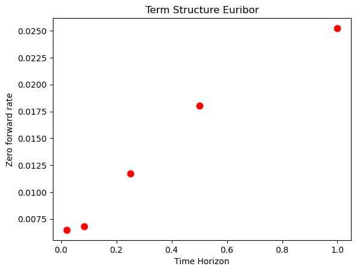

```python
r0 = rates.iloc[0]
factors = 1 + rates.index * rates
zero_rates = 1 / rates.index * np.log(factors)

plt.plot(rates.index, zero_rates, "r.", markersize="15")
plt.xlabel("Time Horizon")
plt.ylabel("Zero forward rate")
plt.title("Term Structure Euribor")
plt.show()
```

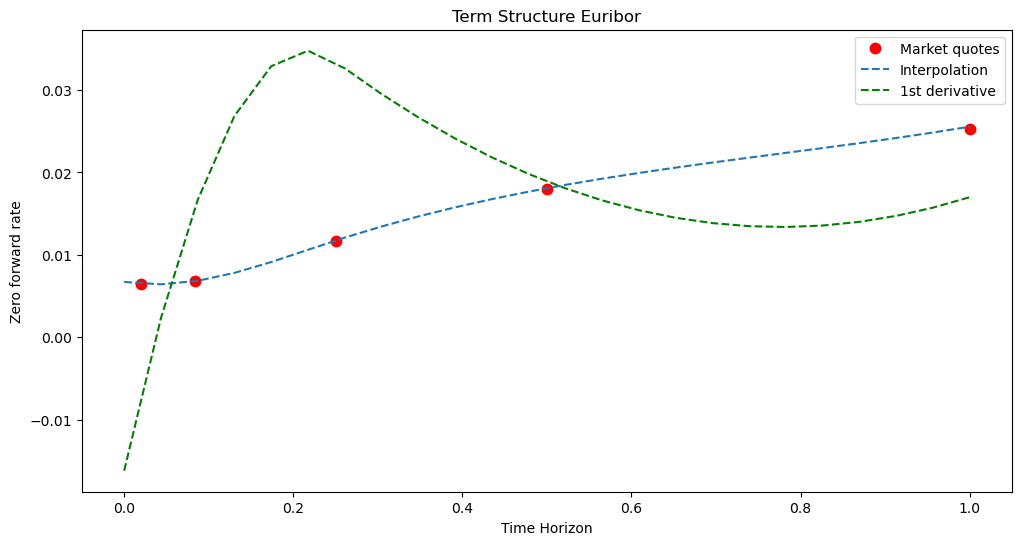

```python
from scipy.interpolate import splev, splrep

bspline = splrep(rates.index, rates, k=3)  # Cubic spline
mat_list_n = np.linspace(
    0.0, 1.0, 24
)  # Create 24 equally spaced maturities between 0 and 1
inter_rates = splev(mat_list_n, bspline, der=0)  # Interpolated rates

first_der = splev(mat_list_n, bspline, der=1)  # First derivative of spline
f = (
    inter_rates + first_der * mat_list_n
)  # Forward rate given interpolated ones and first derivative

plt.figure(figsize=(12, 6))
plt.plot(rates.index, zero_rates, "r.", markersize="15", label="Market quotes")
plt.plot(mat_list_n, inter_rates, "--", markersize="10", label="Interpolation")
plt.plot(mat_list_n, first_der, "g--", markersize="10", label="1st derivative")
plt.xlabel("Time Horizon")
plt.ylabel("Zero forward rate")
plt.title("Term Structure Euribor")
plt.legend()
plt.show()
```

```python
from scipy.optimize import fmin

def CIR_forward_rate(alpha):
    """
    Forward rates in CIR (1985) model
    The set of parameters is called alpha and include Kappa_r, Theta_r and Sigma_r
    """

    kappa_r, theta_r, sigma_r = alpha

    t = mat_list_n
    g = np.sqrt(kappa_r**2 + 2 * sigma_r**2)

    s1 = (kappa_r * theta_r * (np.exp(g * t) - 1)) / (
        2 * g + (kappa_r + g) * (np.exp(g * t) - 1)
    )

    s2 = r0 * (
        (4 * g**2 * np.exp(g * t)) / (2 * g + (kappa_r + g) * (np.exp(g * t)) ** 2)
    )

    return s1 + s2

def CIR_error_function(alpha):
    """
    Error function to calibrate CIR (1985) model
    """

    kappa_r, theta_r, sigma_r = alpha

    # Few remarks to avoid problems for certain values of parameters:
    if 2 * kappa_r * theta_r < sigma_r**2:
        return 100
    if kappa_r < 0 or theta_r < 0 or sigma_r < 0.001:
        return 100

    forward_rates = CIR_forward_rate(alpha)
    MSE = np.sum((f - forward_rates) ** 2) / len(f)

    return MSE

def CIR_calibration():
    opt = fmin(
        CIR_error_function,
        [1.0, 0.02, 0.1],
        xtol=0.00001,
        ftol=0.00001,
        maxiter=300,
        maxfun=500,
    )

    return opt

params = CIR_calibration()
params
```

```
Optimization terminated successfully.
         Current function value: 0.000003
         Iterations: 152
         Function evaluations: 275
```

```
array([0.96521201, 0.11289787, 0.00101249])
```

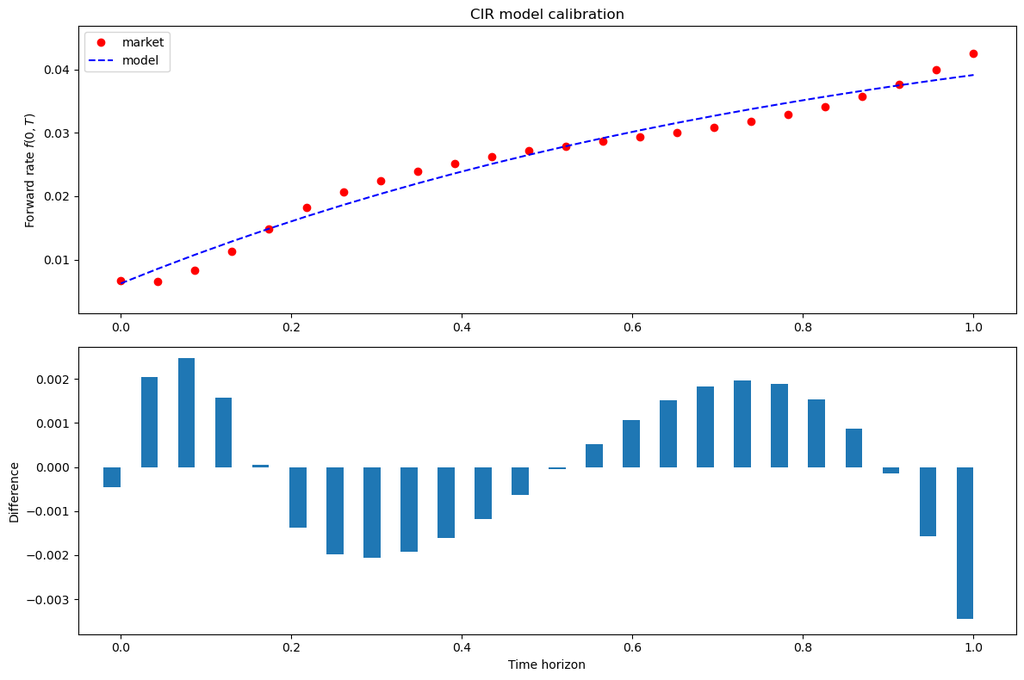

```python
def plot_calibrated_frc(opt):
    """Plots market and calibrated forward rate curves."""
    forward_rates = CIR_forward_rate(opt)
    plt.figure(figsize=(12, 8))
    plt.subplot(211)
    plt.title("CIR model calibration")
    plt.ylabel("Forward rate $f(0,T)$")
    plt.plot(mat_list_n, f, "ro", label="market")
    plt.plot(mat_list_n, forward_rates, "b--", label="model")
    plt.legend(loc=0)
    plt.axis(
        [min(mat_list_n) - 0.05, max(mat_list_n) + 0.05, min(f) - 0.005, max(f) * 1.1]
    )
    plt.subplot(212)
    wi = 0.02
    plt.bar(mat_list_n - wi / 2, forward_rates - f, width=wi)
    plt.xlabel("Time horizon")
    plt.ylabel("Difference")
    plt.axis(
        [
            min(mat_list_n) - 0.05,
            max(mat_list_n) + 0.05,
            min(forward_rates - f) * 1.1,
            max(forward_rates - f) * 1.1,
        ]
    )
    plt.tight_layout()

plot_calibrated_frc(params)
```

# Step 3.b -- as a TEAM

```python
# CIR Interest Rate Monte-Carlo Analysis

M = 100000  # Number of paths for MC
N = 365  # Number of steps
T = 1.0  # Maturity

r0 = 0.648/100

k = 0.96521201
theta = 0.11289787
sigma = 0.00101249

t = np.linspace(0, T, N)

def cir_monte_carlo(r0, k, theta, sigma, T, N, M):
    dt = T / N
    rates = np.zeros((N, M))
    rates[0, :] = r0
    for j in range(M):
        for i in range(1, N):
            dr = (
                k * (theta - rates[i - 1, j]) * dt
                + sigma
                * np.sqrt(dt)
                * np.sqrt(np.maximum(rates[i - 1, j], 0))
                * np.random.normal()
            )
            rates[i, j] = rates[i - 1, j] + dr
    return rates
```

```python
np.random.seed(42)
rates_cir = cir_monte_carlo(r0, k, theta, sigma, T, N, M)
```

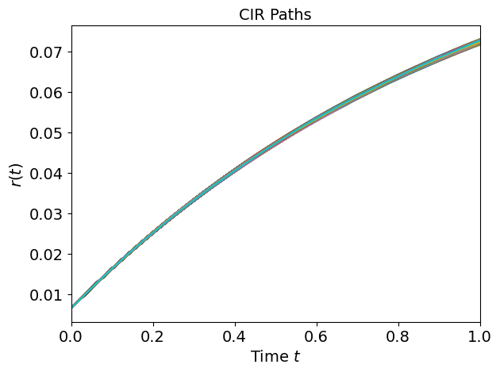

```python
for j in range(M):
    plt.plot(t, rates_cir[:, j])

plt.xlabel("Time $t$", fontsize=14)
plt.ylabel("$r(t)$", fontsize=14)
plt.title("CIR Paths", fontsize=14)
axes = plt.gca()
axes.set_xlim([0, T])
plt.xticks(fontsize=14)
plt.yticks(fontsize=14)
plt.tight_layout()
plt.show()
```

```python
mean_cir = np.mean(rates_cir[364])
mean_cir
```

```
0.07230713365735779
```

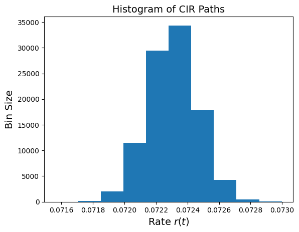

```python
plt.hist(rates_cir[364])
plt.xlabel("Rate $r(t)$", fontsize=14)
plt.ylabel("Bin Size", fontsize=14)
plt.title("Histogram of CIR Paths", fontsize=14)
plt.show()
```

```python
ci = norm(*norm.fit(rates_cir[364])).interval(0.95)
ci
```

```
(0.07200132272209465, 0.07261294459262092)
```